# Broadband policies and outcomes on connectivity

## Research question

- How do **policies** related to broadband (municipal restrictions and state-level funding) affect **connectivity**?
- We would like to test this empirically
- Important in the context of COVID-19 and remote working

## Policy background

- Since the late 1990s, broadband/high speed internet has been deployed almost exclusively by the private sector
- In certain areas, delivery of broadband can be particularly challenging, and coverage has not been even across the United States, with certain areas subject to lower speeds and higher prices
- In some communities, public entities (local governments or public utilities) have stepped in to build broadband networks, either alone or in partnership with private companies

## Controversy

- **Proponents** of municipal broadband: communities/municipalities should have the ability to provide this service
- **Opponents** of municipal broadband: public entities are not equipped and able to efficiently develop, operate and maintain broadband networks, and that funding in this manner is an inefficient allocation of public funds and also creates unfair competition for private developers

## Data (1)

- FCC Form 477 - Internet Access Services
- Broadband Now & Pew Broadband Policy Data Explorer
- 5-year ACS, 2015-2019
- Census Bureau, BLS (controls)

## Data (2)

- Panel data from 2015-2019
- **Connectivity** score (0-5) @ county-level x year
- Municipal broadband **restrictiviness** level (-2-3) @ state-level x year
- Whether state-level **funding** policy in place (0,1) @ state-level x year

## Connectivity over time (state)

[figure not shown]

## Connectivity over time (county)

[figure not shown]

## State level funding

[figure not shown]

## Municipal Restrictions

[figure not shown]

## EDA - Crosstab

| delta_res | avg connectivity change | n |
| --- | --- | --- |
| -3 | 0.0727095 | 75 |
| -1 | 0.0722919 | 303 |
| 0 | 0.0820117 | 2655 |
| 1 | 0.1081789 | 87 |
| 2 | 0.0642857 | 23 |

| delta_funds | avg connect change | n |
| --- | --- | --- |
| -1 | 0.0965054 | 120 |
| 0 | 0.0806671 | 2319 |
| 1 | 0.0814503 | 704 |

## EDA - Scatterplots (1)

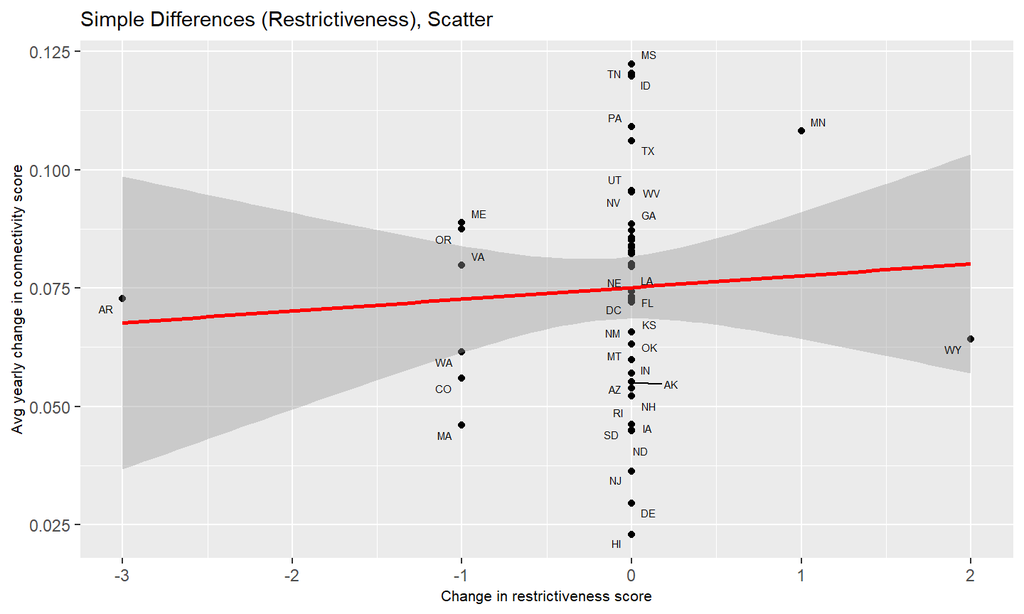

## EDA - Scatterplots (2)

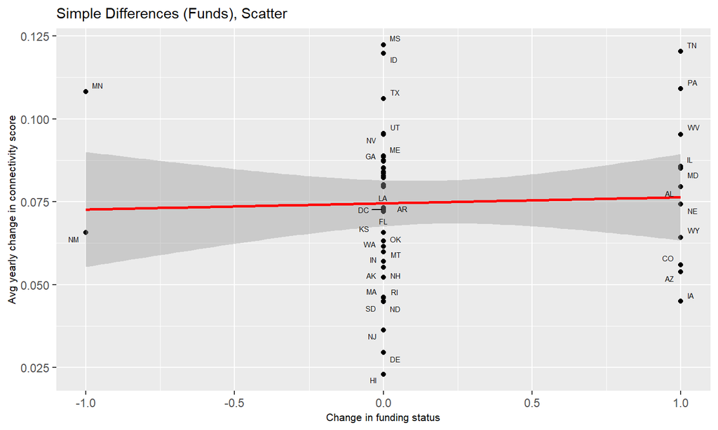

## Simple difference regression (1)

```
##
## ================================================================
##                             Dependent variable:
##             ----------------------------------------------------
##                                delta_connect
##               (1)      (2)      (3)      (4)      (5)      (6)
## ----------------------------------------------------------------
## delta_funds 0.012*** 0.009*** 0.007*** 0.009*** 0.006***  0.002
##             (0.002)  (0.002)  (0.002)  (0.002)  (0.002)  (0.002)
##
## ----------------------------------------------------------------
## IncomeEduc     No      Yes      Yes      Yes      Yes      Yes
## Demographic    No       No      Yes      Yes       No      No
## Labor force    No       No       No      Yes      Yes      Yes
## Political      No       No       No       No      Yes      No
## Geographic     No       No       No       No       No      Yes
## Adjusted R2  0.012    0.167    0.224    0.249    0.200    0.213
## ================================================================
## Note:                                *p<0.1; **p<0.05; ***p<0.01
```

## Simple difference regression (2)

```
##
## ============================================================
##                           Dependent variable:
##             ------------------------------------------------
##                              delta_connect
##               (1)     (2)     (3)     (4)      (5)     (6)
## ------------------------------------------------------------
## delta_res   0.005** -0.003   0.003  0.006*** 0.0002  -0.004*
##             (0.002) (0.002) (0.002) (0.002)  (0.002) (0.002)
##
## ------------------------------------------------------------
## IncomeEduc    No      Yes     Yes     Yes      Yes     Yes
## Demographic   No      No      Yes     Yes      No      No
## Labor force   No      No      No      Yes      Yes     Yes
## Political     No      No      No       No      Yes     No
## Geographic    No      No      No       No      No      Yes
## Adjusted R2  0.001   0.160   0.221   0.245    0.197   0.214
## ============================================================
## Note:                            *p<0.1; **p<0.05; ***p<0.01
```

## Next steps (1)

- **Difference in difference** analysis with, Arkansas x Kentucky, Missouri
- AR large shock: 2011 amendment to the Telecommunications Regulatory Reform Act of 1997; Senate Bill 74 amended the Telecommunications Regulatory Reform Act of 2013
- **Panel regression** analysis with state, time FE
- **Alternative data source** for connections: for a random sample of a quarter of all counties, % of households with access to broadband, over time (and split by income level of household)

## Next steps (2)

- If time permits (it probably won’t), we would also like to look at the relationship between broadband access/speed and **labor market outcomes**, particularly during the COVID-19 pandemic in the United States